# Eye Fitting Straight Lines in the Modern Era (JCGS-22-045)

Data Analysis

Emily A. Robinson, Reka Howard, and Susan VanderPlas

**Rmd file containing code can be accessed [here](https://github.com/earobinson95/Eye-Fitting-Straight-Lines-in-the-Modern-Era/blob/main/analysis/you-draw-it-eyefitting-analysis.Rmd).**

## SETUP

- Load required libraries

```r
# formatting of tables
library(knitr)
library(kableExtra)

# read in data
library(readr)

# data management, plotting, etc.
library(tidyverse)

# used to calculate demming regression equaiton
library(mcr)

# used to fit linear mixed model to residual trend
library(lme4)
library(emmeans)

# used to fit generalized additive mixed model to residual trend
library(mgcv)
```

- Source code to load functions for computing confidence intervals

```r
#' library(lme4)
#' library(mgcv)
#' lmer_model <- lmer(Reaction ~ Days + (Days || Subject), data = sleepstudy)
#' ga_model <- gam(Reaction ~ Days + s(Subject, bs = "re") + s(Days, Subject, bs = "re"),
#'   data = sleepstudy,
#'   method = "REML"
#' )
#'
#' head(
#'   data.frame(
#'     lmer = predict(lmer_model),
#'     gam = predict_gamm(ga_model)
#'   )
#' )
#'
#' head(
#'   cbind(
#'     lmer = predict(lmer_model, re.form = NA),
#'     gam1 = predict_gamm(ga_model, re_form = NA),
#'     gam2 = predict_gamm(ga_model,
#'       exclude = c("s(Subject)", "s(Days,Subject)")
#'     )
#'   )
#' )
#'
#' head(predict_gamm(ga_model, se = TRUE))
#' @export
predict_gamm <- function(
  model,
  newdata,
  re_form = NULL,
  se = FALSE,
  include = NULL,
  exclude = NULL,
  keep_prediction_data = FALSE,
  ...) {

  # Note because predict doesn't use NULL, can't use NULL for new_data arg or
  # even a differently named arg, and I'm not going into the weeds of rlang to
  # find a hack.

  # basic checks
  if (!inherits(model, "gam")) stop("Need a gam object.")

  if (!rlang::is_null(include) && !rlang::is_character(include)) {
    stop("include must be NULL or character.")
  }

  if (!rlang::is_null(exclude) && !rlang::is_character(exclude)) {
    stop("exclude must be NULL or character.")
  }

  if (!rlang::is_null(re_form) &&
      !rlang::is_na(re_form) &
      !rlang::is_character(re_form)) {
    stop("re_form must be NULL, NA, or character.")
  }

  if (any(include %in% exclude)) {
    stop("You can't include and exclude the same thing.")
  }

  if (!rlang::is_logical(se)) {
    stop("se must be TRUE or FALSE")
  }

  if (!rlang::is_logical(keep_prediction_data)) {
    stop("keep_prediction_data must be TRUE or FALSE")
  }

  # standard prediction would simply call predict.gam
  if (rlang::is_null(re_form) | rlang::is_character(re_form)) {
    if (rlang::is_null(re_form)) {
      preds <- predict(model,
                       newdata,
                       se = se,
                       terms = include,
                       exclude = exclude,
                       ...
      )
    } else {
      preds <- predict(model,
                       newdata,
                       se = se,
                       terms = c(include, re_form),
                       exclude = exclude,
                       ...
      )
    }
  } else if (rlang::is_na(re_form)) {

    # FE only
    re_terms <- sapply(model$smooth, function(x) inherits(x, "random.effect"))
    re_terms <- sapply(model$smooth[re_terms], function(x) x$label)

    preds <- predict(model,
                     newdata,
                     se = se,
                     terms = include,
                     exclude = c(re_terms, exclude),
                     ...
    )
  }

  if (se) {
    preds <- data.frame(prediction = preds$fit, se = preds$se)
  } else {
    preds <- data.frame(prediction = preds)
  }

  if (keep_prediction_data) {
    if (missing(newdata)) {
      base <- model$model
    } else {
      base <- newdata
    }
    preds <- data.frame(base, preds)
  }

  preds
}
```

## DATA SIMULATION PROCEDURE

```r
eyefitting_parameter_details <- read_csv("eyefitting-parameter-details.csv")
eyefitting_parameter_details %>% knitr::kable()
```

| parm_id | y_xbar | slope | sigma | x_min | x_max | x_by |
| --- | --- | --- | --- | --- | --- | --- |
| S | 3.88 | 0.66 | 1.3 | 0 | 20 | 0.25 |
| F | 3.90 | 0.66 | 2.8 | 0 | 20 | 0.25 |
| V | 3.89 | 1.98 | 1.5 | 4 | 16 | 0.25 |
| N | 4.11 | -0.70 | 2.5 | 0 | 20 | 0.25 |

```r
linearDataGen <-
  function(y_xbar,
           slope,
           sigma,
           N = 30,
           x_min = 0,
           x_max = 20,
           x_by  = 0.25){

    # Set up x values
    xVals <- seq(x_min, x_max, length.out = floor(N*1))
    xVals <- sample(xVals, N, replace = FALSE)
    xVals <- jitter(xVals)
    xVals <- ifelse(xVals < x_min, x_min, xVals)
    xVals <- ifelse(xVals > x_max, x_max, xVals)

    # From slope intercept form
    # y-y_xbar = m(x-xbar)
    # y = m(x-xbar) + y_xbar = mx - mxbar + y_xbar
    yintercept = y_xbar - slope*mean(xVals)

    # Generate "good" errors
    repeat{
      errorVals <- rnorm(N, 0, sigma)
      if(mean(errorVals[floor(N/3)]) < 2*sigma & mean(errorVals[floor(N/3)] > -2*sigma)){
        break
      }
    }

    # Simulate point data
    point_data <- tibble(dataset = "point_data",
                         x = xVals,
                         y = yintercept + slope*x + errorVals) %>%
      arrange(x)

    # Obtain least squares regression coefficients
    lm.fit <- lm(y ~ x, data = point_data)
    yintercepthat <- coef(lm.fit)[1] %>% as.numeric()
    slopehat <- coef(lm.fit)[2] %>% as.numeric()

    # Simulate best fit line data
    line_data <- tibble(dataset = "line_data",
                        x = seq(x_min, x_max, x_by),
                        y = yintercepthat + slopehat*x)

    data <- list(point_data = point_data, line_data = line_data)

    return(data)
  }

set.seed(68505)
eyefitting_sim_data <- eyefitting_parameter_details %>%
  mutate(data = purrr::pmap(list(y_xbar = y_xbar,
                                 slope = slope,
                                 sigma = sigma,
                                 x_min = x_min,
                                 x_max = x_max,
                                 x_by = x_by), linearDataGen)) %>%
  expand_grid(linear = "true",
              draw_start = 5,
              free_draw = TRUE) %>%
  unnest(data) %>%
  unnest(data)

npoints_data <- eyefitting_sim_data %>%
  filter(dataset == "point_data")
table(npoints_data$parm_id)
```

```
##
##  F  N  S  V
## 30 30 30 30
```

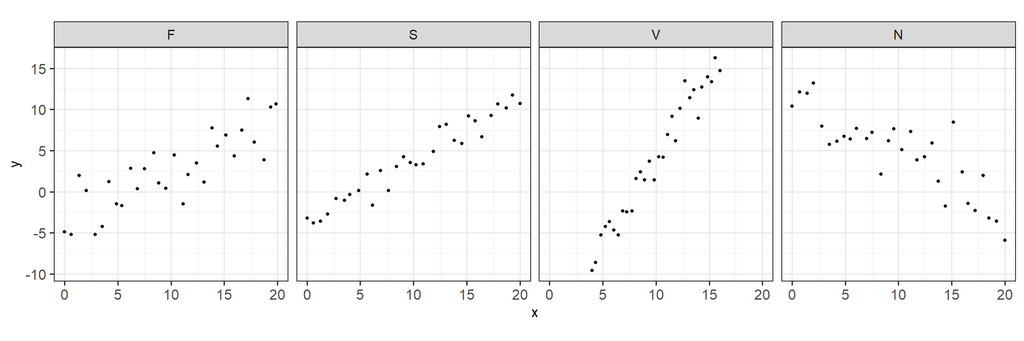

```r
# write.csv(eyefitting_sim_data, "eyefitting-simulated-data-example.csv", row.names = F, na = "")

eyefitting_example_simplot <- eyefitting_sim_data %>%
  filter(dataset == "point_data") %>%
  # filter(dataset %in% c("F", "N", "S") | (x < 16 & x > 4)) %>%
  mutate(parm_id = factor(parm_id, levels = c("F", "S", "V", "N"))) %>%
  dplyr::rename(`Parameter Choice` = parm_id) %>%
  ggplot(aes(x = x, y = y)) +
  geom_point(size = 1) +
  facet_wrap(~`Parameter Choice`, ncol = 4) +
  theme_bw(base_size = 14) +
  theme(aspect.ratio = 1,
  legend.position = "none",
  plot.title   = element_text(size = 12, hjust = 0),
  axis.text    = element_text(size = 12),
  axis.title   = element_text(size = 12),
  legend.title = element_text(size = 12),
  legend.text  = element_text(size = 12),
  # strip.text = element_text(size = 5, margin = margin(0.05,0,0.05,0, "cm")),
  # strip.background = element_rect(size = 0.5),
  legend.key.size = unit(1, "line")
) +
  scale_y_continuous(breaks = seq(-10, 20, 5))
eyefitting_example_simplot
```

## COMPUTE DEMING REGRESSION

This section only needed to be run once to compute the fitted values based on the principal axis (Deming regression). The ordinary least squares fitted values were computed in the original data simulation step. The resulting data set is the `eyefitting-model-data.csv` used for analysis.

```r
# read in feedback and simulated data
eyefitting_feedback_data <- read_csv("https://github.com/earobinson95/Eye-Fitting-Straight-Lines-in-the-Modern-Era/raw/main/analysis/eyefitting-feedback-data.csv")
eyefitting_simulated_data <- read_csv("https://github.com/earobinson95/Eye-Fitting-Straight-Lines-in-the-Modern-Era/raw/main/analysis/eyefitting-simulated-data.csv")

# fit deming regression
demingFit <- function(data){
  fit <- mcreg(data$x, data$y, method.reg = "Deming")
  demingIntercept <- fit@para[1]
  demingSlope     <- fit@para[2]

  return(tibble(demingIntercept = demingIntercept, demingSlope = demingSlope))
}

pca_preds <- eyefitting_simulated_data %>%
  filter(dataset == "point_data", participant_id %in% unique(eyefitting_feedback_data$participant_id)) %>%
  as_tibble() %>%
  tidyr::nest(-c(participant_id, parm_id)) %>%
  dplyr::mutate(deming_fit = purrr::map(data, demingFit)) %>%
  unnest(deming_fit) %>%
  select(participant_id, parm_id, demingIntercept, demingSlope) %>%
  expand_grid(x = seq(0,20,0.25)) %>%
  mutate(ypca = demingIntercept + demingSlope*x)

eyefitting_model_data <- eyefitting_feedback_data %>%
  left_join(pca_preds, by = c("participant_id", "x", "parm_id")) %>%
  mutate(residual_ols_drawn = ydrawn - yols,
         residual_pca_drawn = ydrawn - ypca) %>%
  dplyr::select(nick_name, study_starttime, age, gender, academic_study, recruitment, participant_id, parm_id, plot_id, x, yols, ypca, ydrawn, residual_ols_drawn, residual_pca_drawn)

# save data to csv - already run once and pushed to GitHub.
# write.csv(eyefitting_model_data, file = "../data/eyefitting-model-data.csv", row.names = F, na = "")
```

## PARTICIPANT DATA

De-identified participant data collected in the study and used for analyses are available to be viewed and downloaded from GitHub at [here](https://github.com/earobinson95/Eye-Fitting-Straight-Lines-in-the-Modern-Era/raw/main/data).

```r
eyefitting_model_data  <- read_csv("https://github.com/earobinson95/Eye-Fitting-Straight-Lines-in-the-Modern-Era/raw/main/data/eyefitting-model-data.csv")

factorCols <- c("nick_name", "study_starttime", "age", "gender", "academic_study",
                "recruitment", "participant_id", "parm_id", "plot_id")
eyefitting_model_data[,factorCols] <- lapply(eyefitting_model_data[,factorCols], factor)
```

| nick_name | study_starttime | age | gender | academic_study | recruitment | participant_id | parm_id | plot_id | x | yols | ypca | ydrawn | residual_ols_drawn | residual_pca_drawn |
| --- | --- | --- | --- | --- | --- | --- | --- | --- | --- | --- | --- | --- | --- | --- |
| a43e9f8c045e5762f6396aca7d3484f2 | 1620154415.23688 | 26-30 | Female | Graduate Degree | Direct Email | 0f9fcc784854be73d00970816ffde0e5 | V | 1fa58f3faaa173962e9af0aa98dbeeef | 4.00 | -7.762164 | -8.082525 | -6.883773 | 0.8783913 | 1.1987521 |
| a43e9f8c045e5762f6396aca7d3484f2 | 1620154415.23688 | 26-30 | Female | Graduate Degree | Direct Email | 0f9fcc784854be73d00970816ffde0e5 | V | 1fa58f3faaa173962e9af0aa98dbeeef | 4.25 | -7.278002 | -7.584984 | -6.432879 | 0.8451235 | 1.1521056 |
| a43e9f8c045e5762f6396aca7d3484f2 | 1620154415.23688 | 26-30 | Female | Graduate Degree | Direct Email | 0f9fcc784854be73d00970816ffde0e5 | V | 1fa58f3faaa173962e9af0aa98dbeeef | 4.50 | -6.793840 | -7.087443 | -6.239638 | 0.5542017 | 0.8478051 |
| a43e9f8c045e5762f6396aca7d3484f2 | 1620154415.23688 | 26-30 | Female | Graduate Degree | Direct Email | 0f9fcc784854be73d00970816ffde0e5 | V | 1fa58f3faaa173962e9af0aa98dbeeef | 4.75 | -6.309678 | -6.589902 | -5.853157 | 0.4565204 | 0.7367451 |
| a43e9f8c045e5762f6396aca7d3484f2 | 1620154415.23688 | 26-30 | Female | Graduate Degree | Direct Email | 0f9fcc784854be73d00970816ffde0e5 | V | 1fa58f3faaa173962e9af0aa98dbeeef | 5.00 | -5.825515 | -6.092361 | -5.209022 | 0.6164931 | 0.8833391 |
| a43e9f8c045e5762f6396aca7d3484f2 | 1620154415.23688 | 26-30 | Female | Graduate Degree | Direct Email | 0f9fcc784854be73d00970816ffde0e5 | V | 1fa58f3faaa173962e9af0aa98dbeeef | 5.25 | -5.341353 | -5.594820 | -4.822541 | 0.5188118 | 0.7722791 |
| a43e9f8c045e5762f6396aca7d3484f2 | 1620154415.23688 | 26-30 | Female | Graduate Degree | Direct Email | 0f9fcc784854be73d00970816ffde0e5 | V | 1fa58f3faaa173962e9af0aa98dbeeef | 5.50 | -4.857191 | -5.097279 | -4.500474 | 0.3567170 | 0.5968056 |
| a43e9f8c045e5762f6396aca7d3484f2 | 1620154415.23688 | 26-30 | Female | Graduate Degree | Direct Email | 0f9fcc784854be73d00970816ffde0e5 | V | 1fa58f3faaa173962e9af0aa98dbeeef | 5.75 | -4.373028 | -4.599738 | -4.049579 | 0.3234492 | 0.5501591 |
| a43e9f8c045e5762f6396aca7d3484f2 | 1620154415.23688 | 26-30 | Female | Graduate Degree | Direct Email | 0f9fcc784854be73d00970816ffde0e5 | V | 1fa58f3faaa173962e9af0aa98dbeeef | 6.00 | -3.888866 | -4.102197 | -3.405444 | 0.4834218 | 0.6967531 |
| a43e9f8c045e5762f6396aca7d3484f2 | 1620154415.23688 | 26-30 | Female | Graduate Degree | Direct Email | 0f9fcc784854be73d00970816ffde0e5 | V | 1fa58f3faaa173962e9af0aa98dbeeef | 6.25 | -3.404704 | -3.604656 | -2.503655 | 0.9010485 | 1.1010011 |

## RAW DATA PLOTS

### EXAMPLE

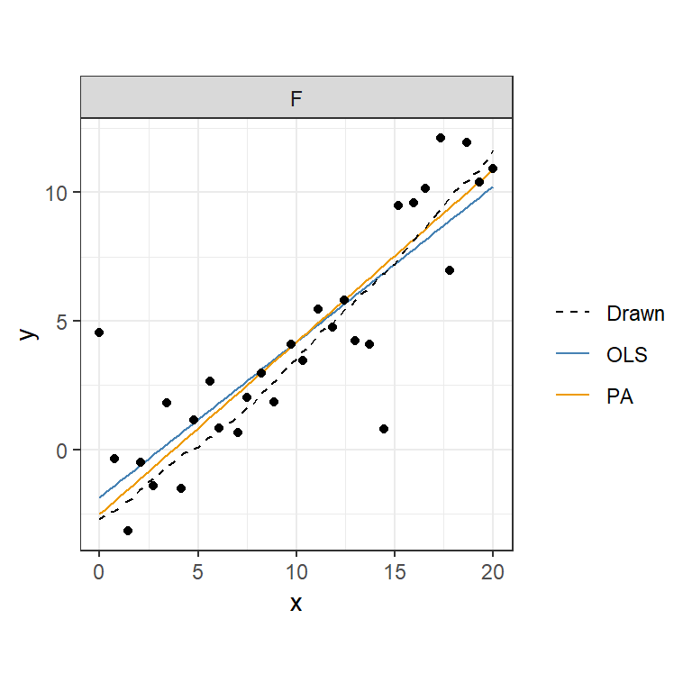

```r
# Example
eyefitting_model_data %>%
  filter(participant_id == "60f510d6896cddc508ea6d3de4b58234", parm_id == "F") %>%
  ggplot(aes(x = x)) +
  geom_line(aes(y = yols, color = "OLS", linetype = "OLS")) +
  geom_line(aes(y = ypca, color = "PA", linetype = "PA")) +
  geom_line(aes(y = ydrawn, color = "Drawn", linetype = "Drawn")) +
  geom_point(data = eyefitting_simulated_data %>%
               filter(dataset == "point_data", participant_id == "60f510d6896cddc508ea6d3de4b58234", parm_id == "F"),
             aes(x = x, y = y)) +
  facet_wrap(~ parm_id) +
  theme_bw() +
  theme(aspect.ratio = 1) +
  scale_y_continuous("y") +
  scale_color_manual("", values = c("black", "steelblue", "orange2")) +
  scale_linetype_manual("", values = c("dashed", "solid", "solid"))
```

### OLS Spaghetti Plot

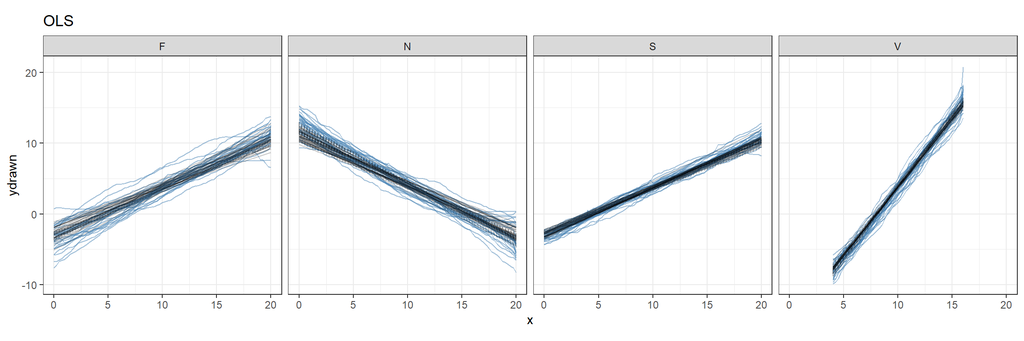

```r
eyefitting_model_data %>%
  ggplot(aes(x = x)) +
  geom_line(aes(y = ydrawn, group = plot_id), alpha = 0.5, color = "steelblue") +
  geom_line(alpha = 0.2, aes(y = yols, group = participant_id)) +
  facet_wrap(~ parm_id, ncol = 4) +
  theme_bw() +
  theme(aspect.ratio = 1) +
  scale_x_continuous(limits = c(0, 20)) +
  ggtitle("OLS")
```

### Principal Axis Spaghetti Plot

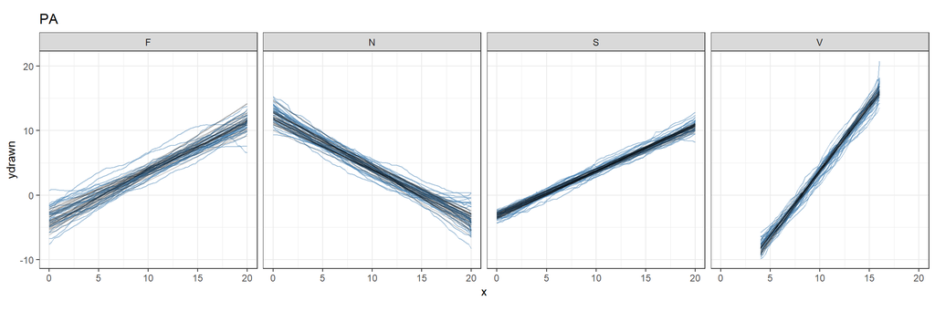

```r
eyefitting_model_data %>%
  ggplot(aes(x = x)) +
  geom_line(aes(y = ydrawn, group = plot_id), alpha = 0.5, color = "steelblue") +
  geom_line(alpha = 0.2, aes(y = ypca, group = participant_id)) +
  facet_wrap(~ parm_id, ncol = 4) +
  theme_bw() +
  theme(aspect.ratio = 1) +
  scale_x_continuous(limits = c(0, 20)) +
  ggtitle("PA")
```

### Residuals Spaghetti Plot

- residualols = ydrawn - yols, denoted $e_{ols}$
- residualpca = ydrawn - ypca, denoted $e_{pca}$

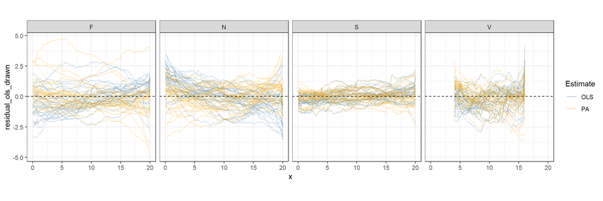

```r
eyefitting_model_data %>%
  ggplot(aes(x = x)) +
  geom_line(aes(y = residual_ols_drawn, group = plot_id, color = "OLS"), alpha = 0.3) +
  geom_line(aes(y = residual_pca_drawn, group = plot_id, color = "PA"), alpha = 0.3) +
  geom_hline(yintercept = 0, linetype = "dashed") +
  facet_wrap(~parm_id, ncol = 4) +
  theme_bw() +
  theme(aspect.ratio = 1) +
  scale_x_continuous(limits = c(0, 20)) +
  scale_color_manual("Estimate", values = c("steelblue", "orange"))
```

## LINEAR CONSTRAINT (Linear Mixed Model)

**Treatments:**

- parm_ID (F, S, V, N)
- x (0, 20)

**Response:** raw residuals

- residualols = ydrawn - yols, denoted $e_{ols}$
- residualpca = ydrawn - ypca, denoted $e_{pca}$

**Experimental Design:**

- Each participant saw each of the 4 plots (new simulated data for each)

**ANOVA Table:**

| SV | DF |
| --- | --- |
| participant_id | (50 - 1) = 49 |
| parm_id | (4 - 1) = 3 |
| x | 1 |
| x:parm_id | (4 - 1) = 3 |
| residual | 143 - by subtraction |

**LMM Model:**

$$y_{drawn} - y_{ols} = e_{ij,ols} = \left[\gamma_0 + \alpha_i\right] + \left[\gamma_{1} x_{ij} + \gamma_{2i} x_{ij}\right] + p_{j} + \epsilon_{ij}$$

- $\gamma_0$ is the overall intercept
- $\alpha_i$ is the effect of the parameter combination on the intercept (i.e. how much the intercept adjusts for each parameter combo)
- $\gamma_1$ is the overall slope for x
- $\gamma_{2i}$ is the effect of the parameter combination on the slope (i.e. think unequal slopes)
- $p_{j} \sim N(0, \sigma^2_{participant})$ is the participant error due to participant variation
- $\epsilon_{ij} \sim N(0, \sigma^2)$ is the residual error.

```r
# OLS
eyefitting.ols.lmer <- lmer(residual_ols_drawn ~ -1 + parm_id + x:parm_id + (1|participant_id),
                       data = eyefitting_model_data)
anova(eyefitting.ols.lmer)
```

```
## Analysis of Variance Table
##           npar  Sum Sq Mean Sq F value
## parm_id      4  123.98   30.99   55.56
## parm_id:x    4 1330.50  332.62  596.26
```

```r
# PCA
eyefitting.pca.lmer <- lmer(residual_pca_drawn ~ -1 + parm_id + x:parm_id + (1|participant_id),
                            data = eyefitting_model_data)
anova(eyefitting.pca.lmer)
```

```
## Analysis of Variance Table
##           npar  Sum Sq Mean Sq F value
## parm_id      4  63.266  15.817  22.197
## parm_id:x    4 237.392  59.348  83.290
```

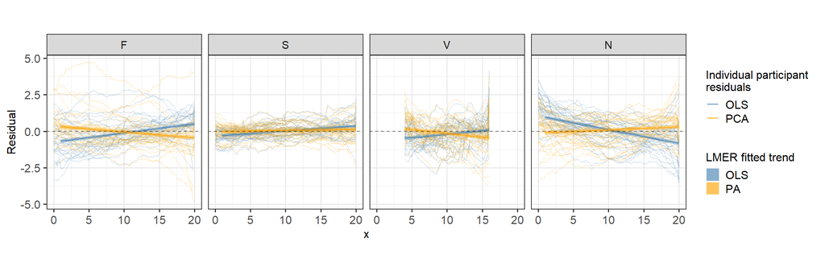

```r
# Obtain Predictions
eyefitting.ols.grid.lmer  <- ref_grid(eyefitting.ols.lmer, at = list(x = seq(1,20,0.5)))
eyefitting.ols.preds.lmer <- emmeans(eyefitting.ols.grid.lmer, ~ parm_id:x, cov.reduce = FALSE) %>%
  as_tibble()

eyefitting.pca.grid.lmer  <- ref_grid(eyefitting.pca.lmer, at = list(x = seq(1,20,0.5)))
eyefitting.pca.preds.lmer <- emmeans(eyefitting.pca.grid.lmer, ~ parm_id:x, cov.reduce = FALSE) %>%
  as_tibble()

eyefitting.preds.lmer <- eyefitting.ols.preds.lmer %>%
  full_join(eyefitting.pca.preds.lmer, by = c("x", "parm_id"), suffix = c(".ols", ".pca"))

# write.csv(eyefitting.preds.lmer, "youdrawit-eyefitting-lmerpred-data.csv", row.names = F, na = "")


# Plot Predictions
eyefitting.lmer.plot <- eyefitting.preds.lmer %>%
  filter((parm_id %in% c("F", "N", "S") | (x <= 16 & x >= 4))) %>%
  mutate(parm_id = factor(parm_id, levels = c("F", "S", "V", "N"))) %>%
  dplyr::rename(`Parameter Choice` = parm_id) %>%
  ggplot(aes(x = x)) +
  geom_line(data = eyefitting_model_data %>% mutate(parm_id = factor(parm_id, levels = c("F", "S", "V", "N"))) %>% dplyr::rename(`Parameter Choice` = parm_id),
            aes(x = x, y = residual_ols_drawn, group = plot_id, color = "OLS"), alpha = 0.2) +
  geom_line(data = eyefitting_model_data %>% mutate(parm_id = factor(parm_id, levels = c("F", "S", "V", "N"))) %>% dplyr::rename(`Parameter Choice` = parm_id),
            aes(x = x, y = residual_pca_drawn, group = plot_id, color = "PCA"), alpha = 0.2) +
  geom_ribbon(aes(ymin = asymp.LCL.ols, ymax = asymp.UCL.ols, fill = "OLS"), color = NA, alpha = 0.4) +
  geom_line(aes(y = emmean.ols, color = "OLS")) +
  geom_ribbon(aes(ymin = asymp.LCL.pca, ymax = asymp.UCL.pca, fill = "PA"), color = NA, alpha = 0.4) +
  geom_line(aes(y = emmean.pca, color = "PCA")) +
  geom_hline(yintercept = 0, linetype = "dashed", alpha = 0.5) +
  facet_wrap(~`Parameter Choice`, ncol = 4) +
  theme_bw(base_size = 14) +
  theme(aspect.ratio = 1,
        legend.position = "right",
        plot.title   = element_text(size = 12, hjust = 0),
        axis.text    = element_text(size = 12),
        axis.title   = element_text(size = 12),
        legend.title = element_text(size = 12),
        legend.text  = element_text(size = 12),
        # strip.text = element_text(size = 5, margin = margin(0.05,0,0.05,0, "cm")),
        # strip.background = element_rect(size = 0.5),
        legend.key.size = unit(1, "line")
        ) +
  scale_y_continuous("Residual") +
  scale_color_manual("Individual participant \nresiduals", values = c("steelblue", "orange"), labels = c("OLS", "PCA")) +
  scale_fill_manual("LMER fitted trend", values = c("steelblue", "orange"), labels = c("OLS", "PA"))

eyefitting.lmer.plot
```

## SMOOTHING SPLINES (Generalized Additive Mixed Model)

**Treatments:**

- parm_ID (F, S, V, N)
- x (0, 20)

**Response:** raw residuals

- residualols = ydrawn - yols, denoted $e_{ols}$
- residualpca = ydrawn - ypca, denoted $e_{pca}$

**Experimental Design:**

- Each participant saw each of the 4 plots (new simulated data for each)

**GAMM Model: fit = OLS, PCA**

$$y_{ijk, drawn} - \hat y_{ijk, fit} = e_{ijk,fit} = \alpha_i + s_{i}(x_{ijk}) + p_{j} + s_{j}(x_{ijk})$$

- $y_{ijk,drawn}$ is the drawn y-value for the $i^{th}$ parameter choice, $j^{th}$ participant, and $k^{th}$ increment of x-value
- $\hat y_{ijk,fit}$ is the fitted y-value for the $i^{th}$ parameter choice, $j^{th}$ participant, and $k^{th}$ increment of x-value corresponding to either the OLS or PCA fit
- $e_{ijk,fit}$ is the residual between the drawn and fitted y-values for the $i^{th}$ parameter choice, $j^{th}$ participant, and $k^{th}$ increment of x-value corresponding to either the OLS or PCA fit
- $\alpha_i$ is the intercept for the parameter choice $i$
- $s_{i}$ is the smoothing spline for the $i^{th}$ parameter choice
- $x_{ijk}$ is the x-value for the $i^{th}$ parameter choice, $j^{th}$ participant, and $k^{th}$ increment
- $p_{j} \sim N(0, \sigma^2_{participant})$ is the error due to participant variation
- $s_{j}$ is the random smoothing spline for each participant.

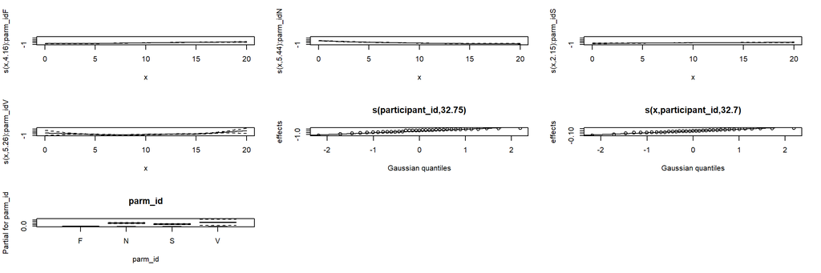

```r
# OLS
eyefitting.ols.gamm <- bam(residual_ols_drawn ~ parm_id + s(x, by = parm_id) +
                             s(participant_id, bs = "re") +
                             s(x,participant_id, bs = "re"),
            method = "REML",
            data = eyefitting_model_data)

# evaluate gamm
plot(eyefitting.ols.gamm, pages = 1, all.terms=TRUE)
```

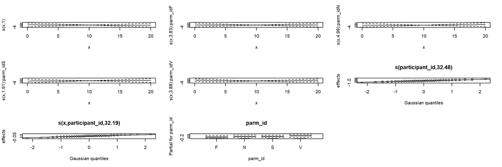

```r
# PCA
eyefitting.pca.gamm <- bam(residual_pca_drawn ~ -1 + parm_id + s(x) +
                             s(x, by = parm_id) +
                             s(participant_id, bs = "re") +
                             s(x,participant_id, bs = "re"),
                           method = "REML",
                           data = eyefitting_model_data)
# evaluate gamm
plot(eyefitting.pca.gamm, pages = 1,all.terms=TRUE)
```

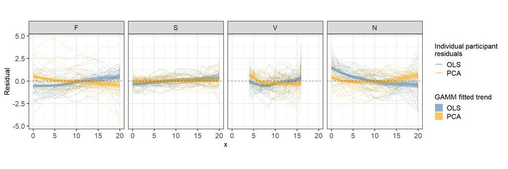

```r
# Obtain Predictions
eyefitting.grid.gamm <- expand_grid(parm_id = c("S", "V", "F", "N"),
                                    x = seq(0,20, 0.5),
                                    participant_id = eyefitting_model_data$participant_id[1])

# OLS
eyefitting.ols.preds <- predict_gamm(eyefitting.ols.gamm, newdata = eyefitting.grid.gamm, se = T, re_form = NA)
eyefitting.grid.gamm$ols.pred <- eyefitting.ols.preds$prediction
eyefitting.grid.gamm$ols.lower <- eyefitting.ols.preds$prediction - (1.96 * eyefitting.ols.preds$se)
eyefitting.grid.gamm$ols.upper <- eyefitting.ols.preds$prediction + (1.96 * eyefitting.ols.preds$se)

# PCA
eyefitting.pca.preds <- predict_gamm(eyefitting.pca.gamm, newdata = eyefitting.grid.gamm, se = T, re_form = NA)
eyefitting.grid.gamm$pca.pred <- eyefitting.pca.preds$prediction
eyefitting.grid.gamm$pca.lower <- eyefitting.pca.preds$prediction - (1.96 * eyefitting.pca.preds$se)
eyefitting.grid.gamm$pca.upper <- eyefitting.pca.preds$prediction + (1.96 * eyefitting.pca.preds$se)

# write.csv(eyefitting.grid.gamm, "youdrawit-eyefitting-gammpred-data.csv", row.names = F, na = "")


# Plot Predictions
eyefitting.gamm.plot <- eyefitting.grid.gamm %>%
  filter((parm_id %in% c("F", "N", "S") | (x <= 16 & x >= 4))) %>%
  mutate(parm_id = factor(parm_id, levels = c("F", "S", "V", "N"))) %>%
  dplyr::rename(`Parameter Choice` = parm_id) %>%
  ggplot(aes(x = x)) +
  geom_line(data = eyefitting_model_data %>% mutate(parm_id = factor(parm_id, levels = c("F", "S", "V", "N"))) %>% dplyr::rename(`Parameter Choice` = parm_id), aes(x = x, y = residual_ols_drawn, group = plot_id, color = "OLS"), alpha = 0.2) +
  geom_line(data = eyefitting_model_data %>% mutate(parm_id = factor(parm_id, levels = c("F", "S", "V", "N"))) %>% dplyr::rename(`Parameter Choice` = parm_id), aes(x = x, y = residual_pca_drawn, group = plot_id, color = "PA"), alpha = 0.2) +
  geom_ribbon(aes(ymin = ols.lower, ymax = ols.upper, fill = "OLS"), color = NA, alpha = 0.4) +
  geom_line(aes(y = ols.pred, color = "OLS")) +
  geom_ribbon(aes(ymin = pca.lower, ymax = pca.upper, fill = "PA"), color = NA, alpha = 0.4) +
  geom_line(aes(y = pca.pred, color = "PA")) +
  geom_hline(yintercept = 0, linetype = "dashed", alpha = 0.5) +
  facet_wrap(~`Parameter Choice`, ncol = 4) +
  theme_bw(base_size = 14) +
  theme(aspect.ratio = 1,
        legend.position = "right",
        plot.title   = element_text(size = 12, hjust = 0),
        axis.text    = element_text(size = 12),
        axis.title   = element_text(size = 12),
        legend.title = element_text(size = 12),
        legend.text  = element_text(size = 12),
        # strip.text = element_text(size = 5, margin = margin(0.05,0,0.05,0, "cm")),
        # strip.background = element_rect(size = 0.5),
        legend.key.size = unit(1, "line")
        ) +
  scale_y_continuous("Residual") +
  scale_color_manual("Individual participant \nresiduals", values = c("steelblue", "orange"), labels = c("OLS", "PCA")) +
  scale_fill_manual("GAMM fitted trend", values = c("steelblue", "orange"), labels = c("OLS", "PCA"))
eyefitting.gamm.plot
```